# Tarea 01

LMT

marzo de 2022

**Fecha de entrega**

Fecha límite de entrega: domingo 27 de marzo de 2022 a las 11:59 pm.

Enviar solución al Classroom de la clase.

## Tarea

### Sección 1.

**Utilicen la herramienta de su preferencia.**

Utilizaremos los datos de la Encuesta ENIGH 2018.

La Encuesta Nacional de Ingresos y Gastos de los Hogares 2018 se llevó a cabo del 21 de agosto al 28 de noviembre de 2018. Su objetivo es proporcionar un panorama estadístico del comportamiento de los **ingresos y gastos de los hogares** en cuanto a su monto, procedencia y distribución; adicionalmente, ofrece información sobre las características ocupacionales y sociodemográficas de los integrantes del hogar, así como las características de la infraestructura de la vivienda y el equipamiento del hogar.

Los datos utilizados pueden ser encontardos en la liga del drive de datos de la clase o en la siguiente página en la cual encontrarán mucho más detalle de los mismos.

[ENIGH 2018](https://www.inegi.org.mx/programas/enigh/nc/2018/#Microdatos).

```r
# Limpiar área de trabajo
rm(list = ls())
```

```r
# Cargar librerías
suppressMessages(library(tidyverse))
library(ggplot2)
library(readr)
library(stringr)
```

Leer los datos

```r
enigh_2018 <- read_csv("/home/leonardo/Documentos/Acatlan/Datos/ENIGH_2018/conjunto_de_datos_concentradohogar_enigh_2018_ns.csv", col_types = cols(folioviv = col_character(), ubica_geo = col_character() ))
```

Sólo conservar ciertas variables ya que no ocuparemos todas. Adicionalmente crearemos una variable para identificar la entidad federativa. Usualmente el INEGI usa una variable tipo carácter de longitud 5 para identificar estado y municipio, los primeros 2 dígitos son la entidad y los últimos 3 son el municipio.

Descripción de las variables:

- folioviv: Identificador de la vivienda.
- foliohog: Código que identifica el hogar.
- ubica_geo: Contiene la ubicación geográfica de la vivienda. Los primeros 2 dígitos representan la clave de la entidad y los siguientes 3 la clave del municipio.
- ing_cor: Ingreso (corriente) trimestral del hogar.
- gasto_mon: Gasto (corriente monetario) trimestral del hogar.

```r
datos <- enigh_2018 %>% select(folioviv,foliohog, ubica_geo, est_dis, upm, factor, ing_cor, gasto_mon) %>%
        mutate(edo_mun = str_pad(ubica_geo,width = 5,side = "left",pad = "0"),
               cve_edo = substr(edo_mun,1,2))

glimpse(datos)
```

```
## Rows: 74,647
## Columns: 10
## $ folioviv  <chr> "100013601", "100013602", "100013603", "100013604", "1000136…
## $ foliohog  <dbl> 1, 1, 1, 1, 1, 1, 1, 1, 1, 1, 1, 1, 1, 1, 1, 1, 1, 1, 1, 1, …
## $ ubica_geo <chr> "1001", "1001", "1001", "1001", "1001", "1001", "1001", "100…
## $ est_dis   <dbl> 2, 2, 2, 2, 2, 2, 2, 2, 2, 2, 2, 2, 2, 2, 2, 2, 2, 2, 2, 2, …
## $ upm       <dbl> 1, 1, 1, 1, 1, 2, 2, 2, 2, 3, 3, 3, 3, 4, 4, 4, 4, 4, 5, 5, …
## $ factor    <dbl> 175, 175, 175, 175, 175, 189, 189, 189, 189, 186, 186, 186, …
## $ ing_cor   <dbl> 76403.70, 42987.73, 580697.74, 46252.71, 53837.09, 237742.54…
## $ gasto_mon <dbl> 18551.47, 55470.99, 103106.89, 19340.06, 13605.03, 33627.70,…
## $ edo_mun   <chr> "01001", "01001", "01001", "01001", "01001", "01001", "01001…
## $ cve_edo   <chr> "01", "01", "01", "01", "01", "01", "01", "01", "01", "01", …
```

**Ejercicios**

0. Identifica que no haya duplicados.
1. Estima el ingreso promedio trimestral de los hogares. Reporta los siguientes 3 datos : Estimación, Error Estándar, Coeficiente de variación. Reflexiona lo siguiente: ¿esperaban ese dato de la estimación?.
2. Estima el gasto promedio trimestral de los hogares. Reporta los siguientes 3 datos : Estimación, Error Estándar, Coeficiente de variación.

El **coeficiente de variación** para una muestra se define de la siguiente manera

$$cv(\hat{\theta})= \frac{(\hat{V}(\hat{\theta}))^\frac{1}{2}}{\hat{\theta}}$$

Es una medida que nos permite medir la variabilidad independientemente de la escala de las variables. Refleja la magnitud relativa que tiene el error estándar con respecto al estimador de referencia, y entre más pequeño sea este valor, mejor es la precisión. Nota. Si bien no existe un consenso unánime sobre qué valores son los más adecuados, el INEGI considera que un dato es de buena calidad si el coeficiente de variación está por debajo de 15%, aceptable si se encuentra entre 15% y 25% y de baja calidad cuando supera el 25%.

3. Hacer estimaciones de por Estado. ¿Cuáles son los 3 estados con ingreso más alto?. ¿Cuáles son los 3 estados con ingreso más bajo?. Si tuvieras que elegir una estimación para el ingreso promedio trimestral por hogar del estado de Chiapas ¿cual elegirías, tu estimación obtenida para ese estado en esta pregunta o la estimación de la pregunta 1?. Explica brevemente tu elección.

Las siguientes líneas le agregan el descriptivo a los códigos de los estados.

```r
cve_edo <-  str_pad(1:32, width = 2,side = "left",pad = "0")
desc_edo <- c("Aguascalientes", "Baja California", "Baja California Sur",
"Campeche", "Coahuila de Zaragoza", "Colima", "Chiapas", "Chihuahua", "Ciudad de México",
"Durango", "Guanajuato", "Guerrero", "Hidalgo", "Jalisco", "Estado de México", "Michoacán de Ocampo",
"Morelos", "Nayarit", "Nuevo León", "Oaxaca", "Puebla", "Querétaro", "Quintana Roo", "San Luis Potosí", "Sinaloa",
"Sonora", "Tabasco", "Tamaulipas", "Tlaxcala", "Veracruz de Ignacio de la Llave", "Yucatán", "Zacatecas")

catalogo_estados <- data_frame(cve_edo = cve_edo,desc_edo = desc_edo)
head(catalogo_estados)
```

```
## # A tibble: 6 x 2
##   cve_edo desc_edo
##   <chr>   <chr>
## 1 01      Aguascalientes
## 2 02      Baja California
## 3 03      Baja California Sur
## 4 04      Campeche
## 5 05      Coahuila de Zaragoza
## 6 06      Colima
```

```r
datos_con_estados <- left_join(datos,catalogo_estados, by = c("cve_edo"))
glimpse(datos_con_estados)
```

```
## Rows: 74,647
## Columns: 11
## $ folioviv  <chr> "100013601", "100013602", "100013603", "100013604", "1000136…
## $ foliohog  <dbl> 1, 1, 1, 1, 1, 1, 1, 1, 1, 1, 1, 1, 1, 1, 1, 1, 1, 1, 1, 1, …
## $ ubica_geo <chr> "1001", "1001", "1001", "1001", "1001", "1001", "1001", "100…
## $ est_dis   <dbl> 2, 2, 2, 2, 2, 2, 2, 2, 2, 2, 2, 2, 2, 2, 2, 2, 2, 2, 2, 2, …
## $ upm       <dbl> 1, 1, 1, 1, 1, 2, 2, 2, 2, 3, 3, 3, 3, 4, 4, 4, 4, 4, 5, 5, …
## $ factor    <dbl> 175, 175, 175, 175, 175, 189, 189, 189, 189, 186, 186, 186, …
## $ ing_cor   <dbl> 76403.70, 42987.73, 580697.74, 46252.71, 53837.09, 237742.54…
## $ gasto_mon <dbl> 18551.47, 55470.99, 103106.89, 19340.06, 13605.03, 33627.70,…
## $ edo_mun   <chr> "01001", "01001", "01001", "01001", "01001", "01001", "01001…
## $ cve_edo   <chr> "01", "01", "01", "01", "01", "01", "01", "01", "01", "01", …
## $ desc_edo  <chr> "Aguascalientes", "Aguascalientes", "Aguascalientes", "Aguas…
```

4. **(opcional)**. Utiliza las estimaciones de la pregunta 3 para hacer una grafica de barras horizontales. Grafica los datos en orden descendente.
5. **(opcional)**. (Ingreso vs Gasto) Hacer una grafica de dispersión del ingreso vs gasto por hogar para los hogares que tienen ingreso menor a la estimación obtenida en la primera pregunta.
6. **(opcional)**. Graficar los histogramas del ingreso y gasto en la misma grafica. Fijar el eje x de cero a 250 mil.
7. Utilizar los datos que hemos visto en clase de **House Prices**. Crear 100 muestras de tamaño 150 y obtener el intervalo de confianza (al 90%) del precio promedio para cada una de las muestras. Graficar los intervalos para obtener una grafica similar a la siguiente imagen.

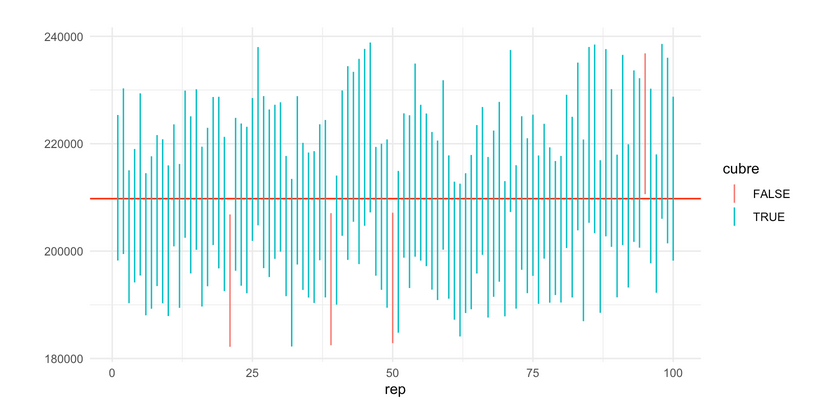

grafica intervalos

### Sección 2.

**Utilicen SAS.**

8. Utilizar los datos del [censo 2010](https://www.inegi.org.mx/programas/ccpv/2010/#Microdatos) de la tabla de personas del Estado de México para crear una grafica de dispersión de la edad de la persona vs la edad de su madre. Para identificar las variables que les ayudarán para este ejercicio consulten el diccionario del cuestionario ubicado en el mismo vínculo que los datos. No a todas las personass podrán asignarles la edad de su madre, sólo conserven los registros donde tengan dato tanto de la persona como de su madre.

Nota. La grafica en SAS es opcional, lo importante es crear la tabla con la edad de la persona y la edad de su madre. Con la tabla obtenida, la grafica debería verse similar a la siguiente imagen.

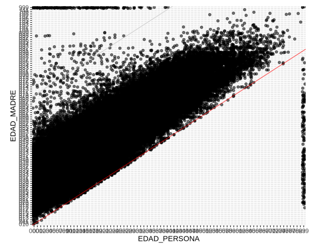

grafica dispersión

9. Utilizar los datos de la tabla de personas de la Ciudad de México para crear una tabla por grupos de edad y sexo. Utilizar grupos de edad quinquenales. La tabla debe tener 4 columnas: grupos de edad, total, hombres, mujeres. La siguienteimagen puede servir de referencia.

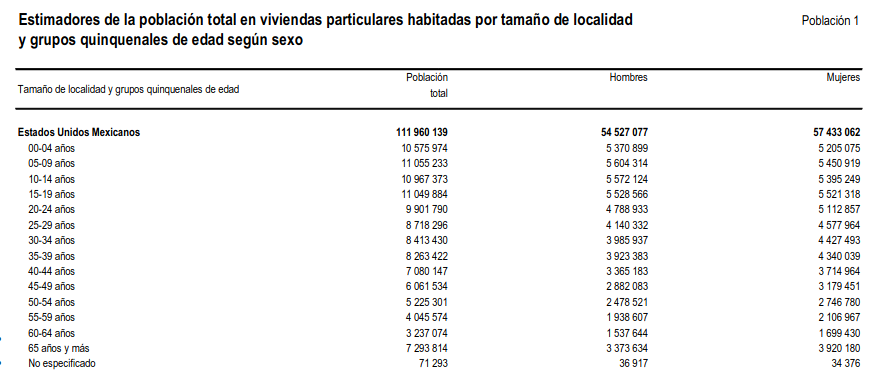

tabulado